# Midterm

## Mid term project

Assume that a large bowl contains an arbitrary number of balls of aribtrary colors.

Our goal is to create a class, namely `Bowl`, that simulates the color distribution of $n$ numbers of randomly selected balls.

The object of this class is created by receiving the color and number of balls as variable arguments.

For example, simulation result may be like this:

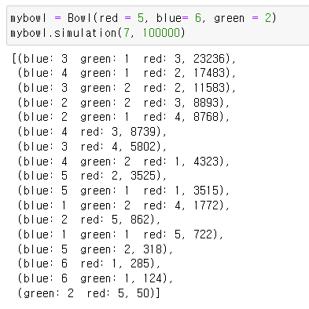

### Details

- Implement `__repr__` method
- Implement `__eq__` method to overload `==`
- Implement `__add__` method to overload `+` that combines two `bowl`s
- Implement `fetch` method that draw balls randomly with given number as a argument and the return type is `bowl`
- Implement `__getitem__` such that we can find the number of balls of a specific color, for example, `my_bowl["red"]`, which shows the number of red balls.
- Implement `simulation` method

### Ordered bowl

- Define a class `OrderedBowl`. `OrderedBowl` inherits from `Bowl`.
- `OrderedBowl` has an additional atrribute, that keeps the order of colored balls.
- Override the methods `__repr__`, `__eq__`, `__add__` properly in `OrderedBowl`.
- Override the method `__getitem__` in `OrderedBowl` such that we can find the color of the ball at a specific integer index, for example, `my_orderd_bowl[1]` which shows the color of 2nd ball in the orderd bowl.
- Define a class method `by_Bowl` which can create a `OrderedBowl` from `Bowl`
- Define a method `ordered_fetch` which returns a `OrderdBowl`
- Compute the approximate probabilty via a simulation of the follwoing question.
  - There are 6 black balls and 2 white balls in the `Bowl`.
  - Calculate the probability of getting a black ball in the second draw, given that the first draw results in a white ball.

### Further consideration

- You may implement getter, setter, deleter method, if you need.
- You are free to implement the parts not specifically mentioned above.